# Summer Internship

Navin Ramanan

6/01/2022

##Setup

1. Map Ensembl ID to Gene Symbol in the counts file
2. Write Counts Data with Gene Symbol to CSV
3. Reading and filtering Hippocampus count and metadata files
4. Reading and filtering Cortex count and metadata files
5. Cortex: APP=WT, Age=6, Diet=Control vs Supplemented (~APP + Age + Diet) WT6Control vs WT6Supplemented

```
## Cortex: Running DESeq2 for Diet(Control vs Supplemented) with APP=WT, Age=6:padj < 0.05 and 0.10
```

```
## Cortex: WT6Control vs WT6Supplemented
```

```
## resultsNames:
```

```
##  [1] "Intercept"
##  [2] "group_APP12Supplemented_vs_APP12Control"
##  [3] "group_APP3Control_vs_APP12Control"
##  [4] "group_APP3Supplemented_vs_APP12Control"
##  [5] "group_APP6Control_vs_APP12Control"
##  [6] "group_APP6Supplemented_vs_APP12Control"
##  [7] "group_APP9Control_vs_APP12Control"
##  [8] "group_APP9Supplemented_vs_APP12Control"
##  [9] "group_WT12Control_vs_APP12Control"
## [10] "group_WT12Supplemented_vs_APP12Control"
## [11] "group_WT3Control_vs_APP12Control"
## [12] "group_WT3Supplemented_vs_APP12Control"
## [13] "group_WT6Control_vs_APP12Control"
## [14] "group_WT6Supplemented_vs_APP12Control"
## [15] "group_WT9Control_vs_APP12Control"
## [16] "group_WT9Supplemented_vs_APP12Control"
## [1] "group"           "WT6Control"      "WT6Supplemented"
##
## out of 34880 with nonzero total read count
## adjusted p-value < 0.1
## LFC > 0 (up)       : 1, 0.0029%
## LFC < 0 (down)     : 0, 0%
## outliers [1]       : 101, 0.29%
## low counts [2]     : 0, 0%
## (mean count < 0)
## [1] see 'cooksCutoff' argument of ?results
## [2] see 'independentFiltering' argument of ?results
```

```
## log2 fold change (MLE): group WT6Control vs WT6Supplemented
## Wald test p-value: group WT6Control vs WT6Supplemented
## DataFrame with 10 rows and 6 columns
##                       baseMean log2FoldChange     lfcSE      stat      pvalue
##                      <numeric>      <numeric> <numeric> <numeric>   <numeric>
## ENSMUSG00000105481    1.861372      16.506774  2.381378  6.931606 4.16089e-12
## ENSMUSG00000115060    3.283896       4.398386  1.096078  4.012839 5.99928e-05
## ENSMUSG00000034898  396.196913      -0.988425  0.250534 -3.945279 7.97070e-05
## ENSMUSG00000064380    4.058887      -5.057340  1.248018 -4.052296 5.07175e-05
## ENSMUSG00000068129 1858.897066       1.746922  0.455313  3.836751 1.24673e-04
## ENSMUSG00000027971  352.207519      -3.226194  0.839257 -3.844107 1.20992e-04
## ENSMUSG00000119895  185.910008      -5.093085  1.354605 -3.759831 1.70028e-04
## ENSMUSG00000044201   19.879803      -2.046477  0.550905 -3.714752 2.03403e-04
## ENSMUSG00000102628   17.922102      -0.312185  0.469099 -0.665500 5.05731e-01
## ENSMUSG00000097426    0.160601      -0.839426  8.245409 -0.101805 9.18911e-01
##                           padj
##                      <numeric>
## ENSMUSG00000105481 1.44712e-07
## ENSMUSG00000115060 6.93033e-01
## ENSMUSG00000034898 6.93033e-01
## ENSMUSG00000064380 6.93033e-01
## ENSMUSG00000068129 7.22666e-01
## ENSMUSG00000027971 7.22666e-01
## ENSMUSG00000119895 8.44773e-01
## ENSMUSG00000044201 8.84268e-01
## ENSMUSG00000102628 1.00000e+00
## ENSMUSG00000097426 1.00000e+00
```

```
## log2 fold change (MLE): group WT6Control vs WT6Supplemented
## Wald test p-value: group WT6Control vs WT6Supplemented
## DataFrame with 34880 rows and 6 columns
##                       baseMean log2FoldChange     lfcSE      stat      pvalue
##                      <numeric>      <numeric> <numeric> <numeric>   <numeric>
## ENSMUSG00000105481     1.86137      16.506774  2.381378   6.93161 4.16089e-12
## ENSMUSG00000115060     3.28390       4.398386  1.096078   4.01284 5.99928e-05
## ENSMUSG00000034898   396.19691      -0.988425  0.250534  -3.94528 7.97070e-05
## ENSMUSG00000064380     4.05889      -5.057340  1.248018  -4.05230 5.07175e-05
## ENSMUSG00000068129  1858.89707       1.746922  0.455313   3.83675 1.24673e-04
## ...                        ...            ...       ...       ...         ...
## ENSMUSG00000109212    0.769426       0.000000  8.245409  0.000000          NA
## ENSMUSG00000054134   40.269651      -0.954959  0.769370 -1.241222          NA
## ENSMUSG00000024028    0.789155       0.000000  8.245409  0.000000          NA
## ENSMUSG00000061808 1664.189531       0.197970  0.829098  0.238778          NA
## ENSMUSG00000037451    1.547250       0.000000  8.245409  0.000000          NA
##                           padj
##                      <numeric>
## ENSMUSG00000105481 1.44712e-07
## ENSMUSG00000115060 6.93033e-01
## ENSMUSG00000034898 6.93033e-01
## ENSMUSG00000064380 6.93033e-01
## ENSMUSG00000068129 7.22666e-01
## ...                        ...
## ENSMUSG00000109212          NA
## ENSMUSG00000054134          NA
## ENSMUSG00000024028          NA
## ENSMUSG00000061808          NA
## ENSMUSG00000037451          NA
```

```
## class: DESeqDataSet
## dim: 34880 96
## metadata(1): version
## assays(4): counts mu H cooks
## rownames(34880): ENSMUSG00000102628 ENSMUSG00000097426 ...
##   ENSMUSG00000095041 ENSMUSG00000095742
## rowData names(78): baseMean baseVar ... deviance maxCooks
## colnames(96): 102 103 ... 95 96
## colData names(6): Sex Diet ... group sizeFactor
```

```
## Cortex DESeq2 result is saved in file: 'Cortex_deseq_results_Diet_WT_6.csv'
```

```
## Cortex DESeq2 normalized counts is saved in file: 'Cortex_deseq_norm_counts_Diet_WT_6.csv'
```

```
## Cortex DESeq2 result with Gene names (mgi_symbols) is saved in file: 'Cortex_deseq_results_with_genename_Diet_WT_6.csv'
```

```
## [1] 34880
```

```
## [1] 1
```

```
## Cortex DESeq2 result after padj (0.05) filtering is saved in file: 'Cortex_deseq_results_Diet_WT_6_padj_05_filtered.csv'
```

```
## Number of DE genes significant at padj < 0.05 for Cortex:WT6Control vs WT6Supplemented: 1
```

```
## Number of DE genes discarded after padj threshold 0.05 filtering for Cortex:WT6Control vs WT6Supplemented: 34879
```

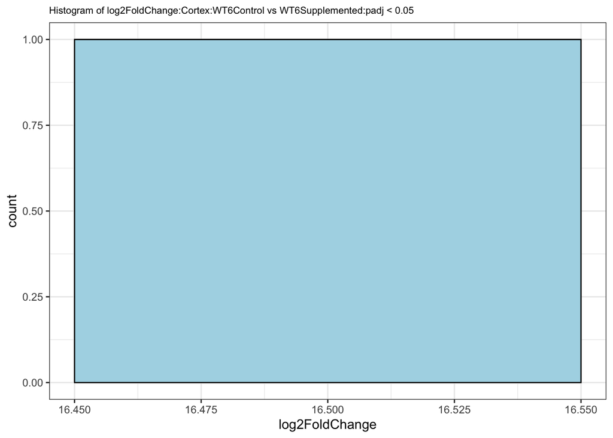

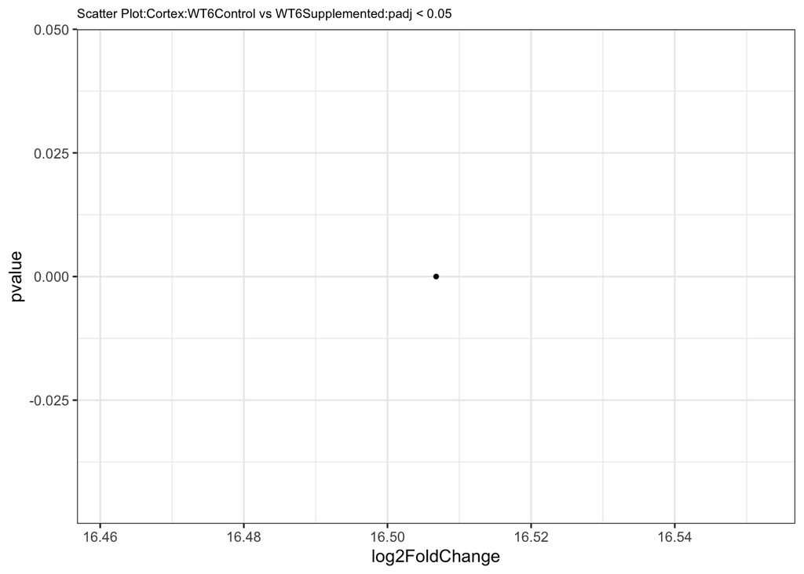

```
## [1] 34880
```

```
## [1] 1
```

```
## Cortex DESeq2 result after padj (0.1) filtering is saved in file: 'Cortex_deseq_results_Diet_WT_6_padj_1_filtered.csv'
```

```
## Number of DE genes significant at padj < 0.1 for Cortex:WT6Control vs WT6Supplemented: 1
```

```
## Number of DE genes discarded after padj threshold 0.1 filtering for Cortex:WT6Control vs WT6Supplemented: 34879
```

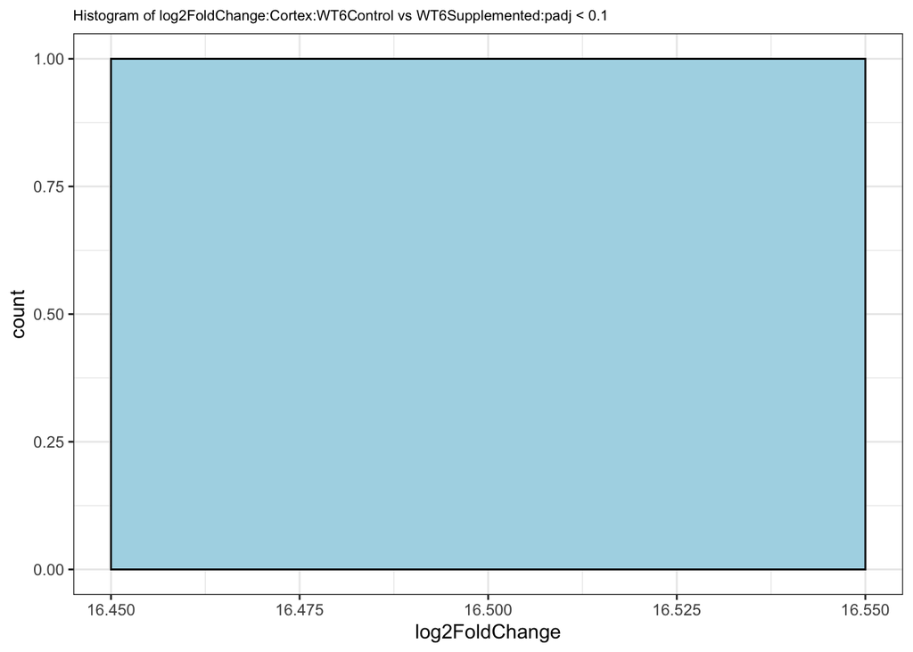

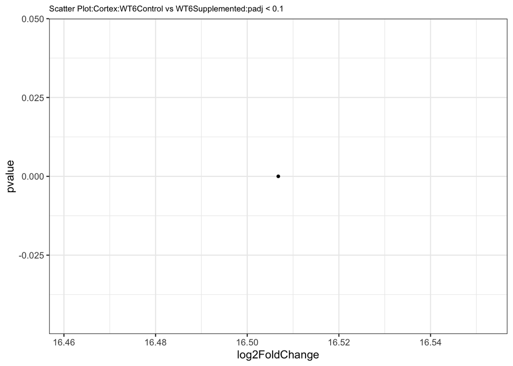

6. Cortex: Enhanced Volcano Plot

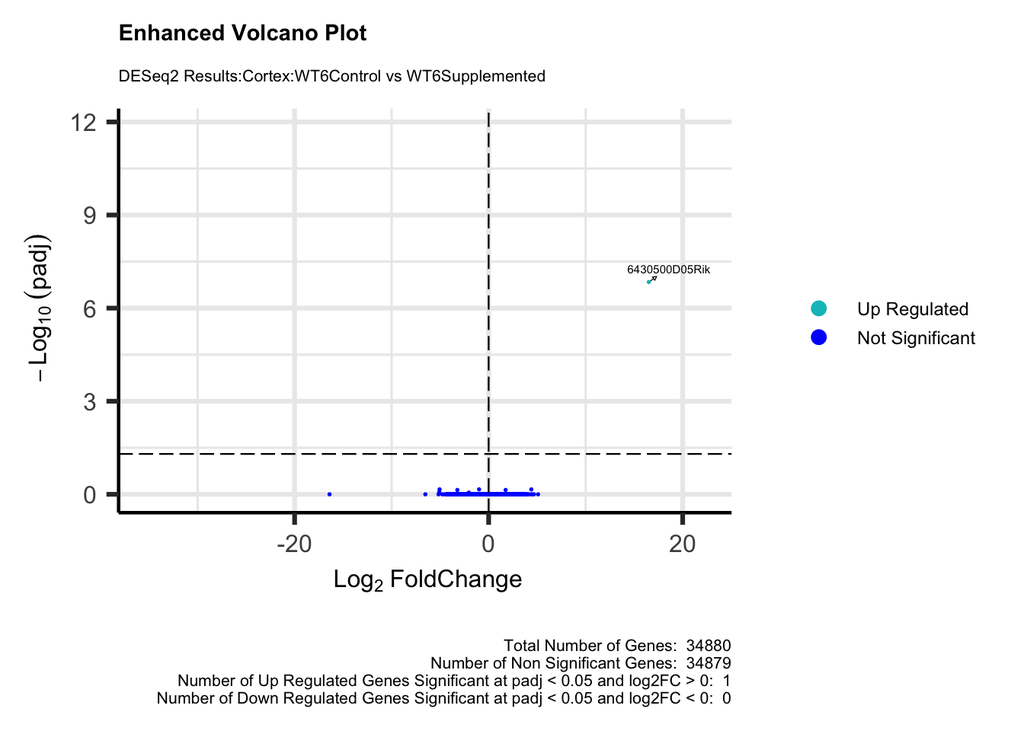

7. Cortex: Heatmap

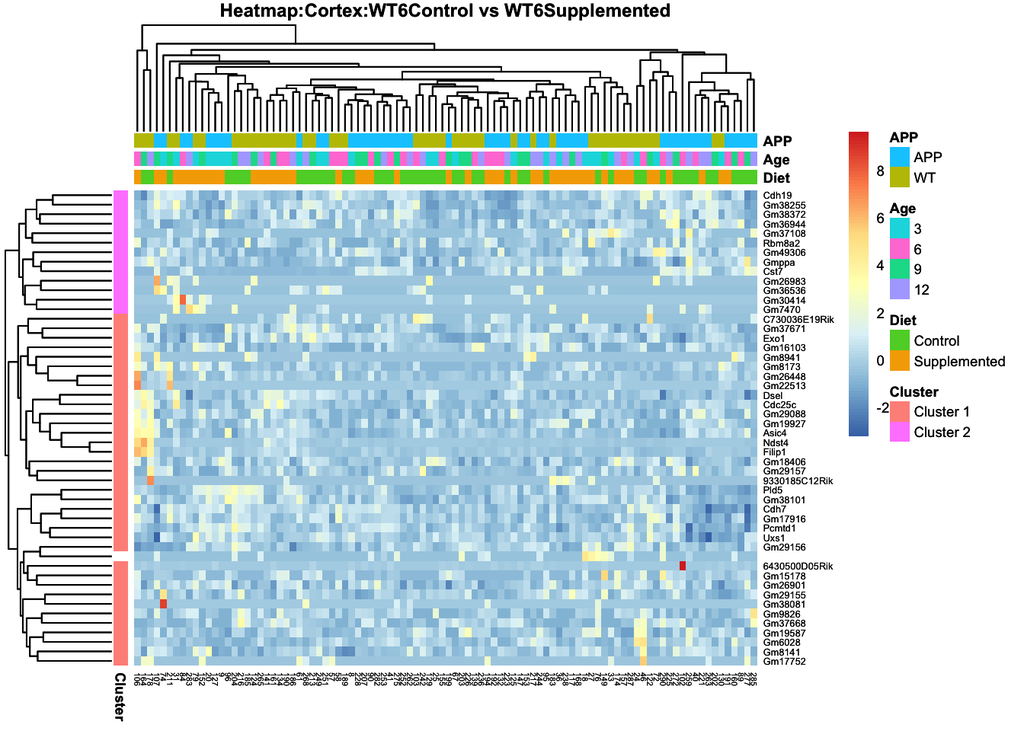

8. Hippocampus: APP=WT, Age=6, Diet=Control vs Supplemented (~APP + Age + Diet) WT6Control vs WT6Supplemented

```
## Hippocampus: Running DESeq2 for Diet(Control vs Supplemented) with APP=WT, Age=6:padj < 0.05 and 0.10
```

```
## Hippocampus: WT6Control vs WT6Supplemented
```

```
## resultsNames:
```

```
##  [1] "Intercept"
##  [2] "group_APP12Supplemented_vs_APP12Control"
##  [3] "group_APP3Control_vs_APP12Control"
##  [4] "group_APP3Supplemented_vs_APP12Control"
##  [5] "group_APP6Control_vs_APP12Control"
##  [6] "group_APP6Supplemented_vs_APP12Control"
##  [7] "group_APP9Control_vs_APP12Control"
##  [8] "group_APP9Supplemented_vs_APP12Control"
##  [9] "group_WT12Control_vs_APP12Control"
## [10] "group_WT12Supplemented_vs_APP12Control"
## [11] "group_WT3Control_vs_APP12Control"
## [12] "group_WT3Supplemented_vs_APP12Control"
## [13] "group_WT6Control_vs_APP12Control"
## [14] "group_WT6Supplemented_vs_APP12Control"
## [15] "group_WT9Control_vs_APP12Control"
## [16] "group_WT9Supplemented_vs_APP12Control"
## [1] "group"           "WT6Control"      "WT6Supplemented"
##
## out of 33271 with nonzero total read count
## adjusted p-value < 0.1
## LFC > 0 (up)       : 2, 0.006%
## LFC < 0 (down)     : 0, 0%
## outliers [1]       : 77, 0.23%
## low counts [2]     : 0, 0%
## (mean count < 0)
## [1] see 'cooksCutoff' argument of ?results
## [2] see 'independentFiltering' argument of ?results
```

```
## log2 fold change (MLE): group WT6Control vs WT6Supplemented
## Wald test p-value: group WT6Control vs WT6Supplemented
## DataFrame with 10 rows and 6 columns
##                       baseMean log2FoldChange     lfcSE       stat      pvalue
##                      <numeric>      <numeric> <numeric>  <numeric>   <numeric>
## ENSMUSG00000066720    5.439557     21.0787079  2.789264  7.5570849 4.12203e-14
## ENSMUSG00000086756    5.466017     20.7566109  3.411639  6.0840579 1.17178e-09
## ENSMUSG00000102628    4.933073     -0.1042623  0.700405 -0.1488601 8.81664e-01
## ENSMUSG00000086053    1.288311     -1.8824789  1.710363 -1.1006314 2.71057e-01
## ENSMUSG00000102135    0.260071     -0.4431545  4.959492 -0.0893548 9.28800e-01
## ENSMUSG00000100764    7.786530     -0.5831790  0.683172 -0.8536342 3.93308e-01
## ENSMUSG00000100635   10.643846      1.1900769  0.997996  1.1924667 2.33078e-01
## ENSMUSG00000100480   40.881695     -0.4302322  0.331608 -1.2974129 1.94489e-01
## ENSMUSG00000100025    9.761216     -0.2302399  0.498188 -0.4621543 6.43971e-01
## ENSMUSG00000051285 7467.607010      0.0486407  0.225264  0.2159273 8.29044e-01
##                           padj
##                      <numeric>
## ENSMUSG00000066720 1.36827e-09
## ENSMUSG00000086756 1.94481e-05
## ENSMUSG00000102628 1.00000e+00
## ENSMUSG00000086053 1.00000e+00
## ENSMUSG00000102135 1.00000e+00
## ENSMUSG00000100764 1.00000e+00
## ENSMUSG00000100635 1.00000e+00
## ENSMUSG00000100480 1.00000e+00
## ENSMUSG00000100025 1.00000e+00
## ENSMUSG00000051285 1.00000e+00
```

```
## log2 fold change (MLE): group WT6Control vs WT6Supplemented
## Wald test p-value: group WT6Control vs WT6Supplemented
## DataFrame with 33271 rows and 6 columns
##                       baseMean log2FoldChange     lfcSE       stat      pvalue
##                      <numeric>      <numeric> <numeric>  <numeric>   <numeric>
## ENSMUSG00000066720    5.439557      21.078708  2.789264  7.5570849 4.12203e-14
## ENSMUSG00000086756    5.466017      20.756611  3.411639  6.0840579 1.17178e-09
## ENSMUSG00000102628    4.933073      -0.104262  0.700405 -0.1488601 8.81664e-01
## ENSMUSG00000086053    1.288311      -1.882479  1.710363 -1.1006314 2.71057e-01
## ENSMUSG00000102135    0.260071      -0.443155  4.959492 -0.0893548 9.28800e-01
## ...                        ...            ...       ...        ...         ...
## ENSMUSG00000068196   434.29152        3.80444   1.19706   3.178155          NA
## ENSMUSG00000053375     1.58633        2.11665   3.22713   0.655891          NA
## ENSMUSG00000023122    38.89638        7.10355   2.56699   2.767264          NA
## ENSMUSG00000023943    18.46229        6.81125   2.72466   2.499852          NA
## ENSMUSG00000061808 34756.71162        6.30475   1.53479   4.107889          NA
##                           padj
##                      <numeric>
## ENSMUSG00000066720 1.36827e-09
## ENSMUSG00000086756 1.94481e-05
## ENSMUSG00000102628 1.00000e+00
## ENSMUSG00000086053 1.00000e+00
## ENSMUSG00000102135 1.00000e+00
## ...                        ...
## ENSMUSG00000068196          NA
## ENSMUSG00000053375          NA
## ENSMUSG00000023122          NA
## ENSMUSG00000023943          NA
## ENSMUSG00000061808          NA
```

```
## class: DESeqDataSet
## dim: 33271 96
## metadata(1): version
## assays(4): counts mu H cooks
## rownames(33271): ENSMUSG00000102628 ENSMUSG00000086053 ...
##   ENSMUSG00000095041 ENSMUSG00000095742
## rowData names(78): baseMean baseVar ... deviance maxCooks
## colnames(96): 102 103 ... 95 96
## colData names(6): Sex Diet ... group sizeFactor
```

```
## Hippocampus DESeq2 result is saved in file: 'Hippocampus_deseq_results_Diet_WT_6.csv'
```

```
## Hippocampus DESeq2 normalized counts is saved in file: 'Hippocampus_deseq_norm_counts_Diet_WT_6.csv'
```

```
## Hippocampus DESeq2 result with Gene names (mgi_symbols) is saved in file: 'Hippocampus_deseq_results_with_genename_Diet_WT_6.csv'
```

```
## Hippocampus DESeq2 result after padj (0.05) filtering is saved in file: 'Hippocampus_deseq_results_Diet_WT_6_padj_05_filtered.csv'
```

```
## Number of DE genes significant at padj < 0.05 for Hippocampus:WT6Control vs WT6Supplemented: 2
```

```
## Number of DE genes discarded after padj threshold < 0.05 filtering for Hippocampus:WT6Control vs WT6Supplemented: 33269
```

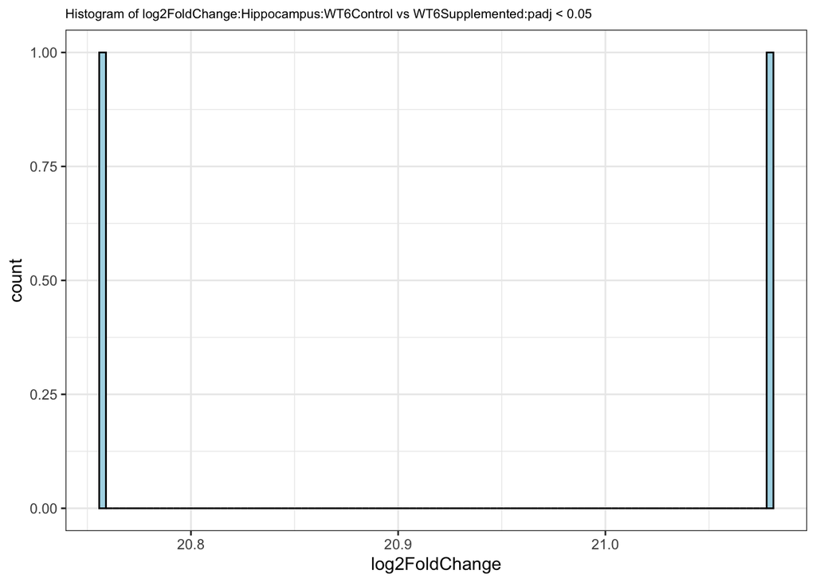

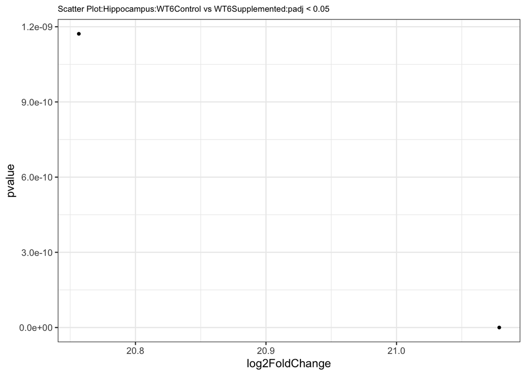

```
## Hippocampus DESeq2 result after padj (0.1) filtering is saved in file: 'Hippocampus_deseq_results_Diet_WT_6_padj_1_filtered.csv'
```

```
## Number of DE genes significant at padj < 0.1 for Hippocampus:WT6Control vs WT6Supplemented: 2
```

```
## Number of DE genes discarded after padj threshold < 0.1 filtering for Hippocampus:WT6Control vs WT6Supplemented: 33269
```

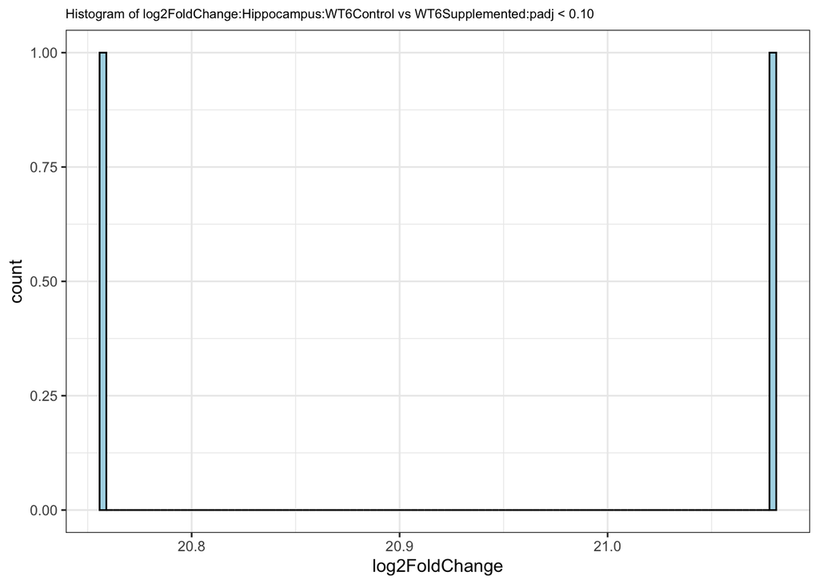

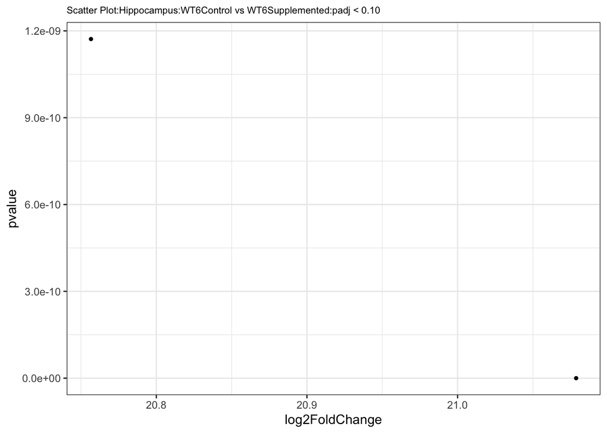

9. Hippocampus: Enhanced Volcano Plot

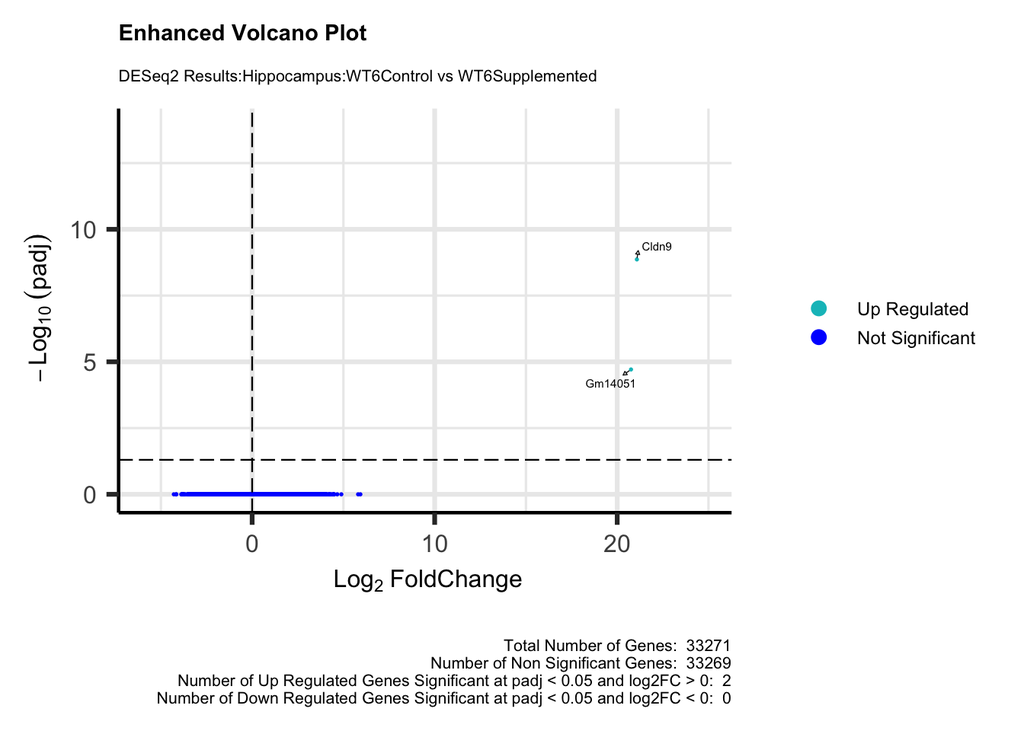

10. Hippocampus: Heatmap

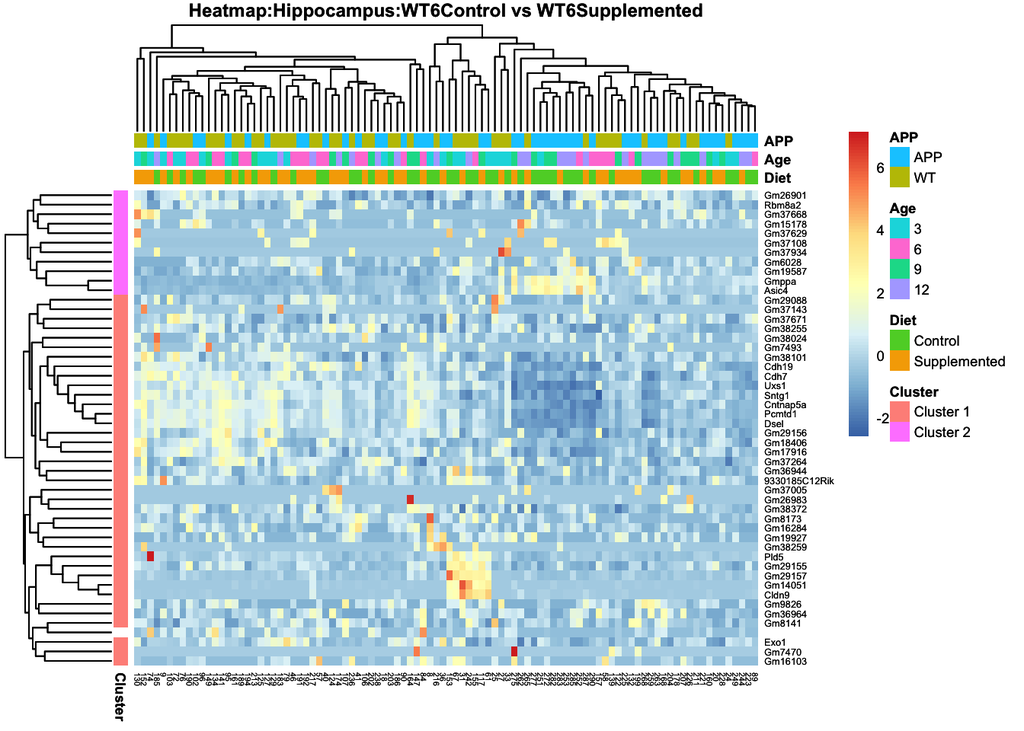

11. GSEA:Running fgsea

Perform a GSEA using a ranked list log2FoldChange values for all genes discovered in the DESeq2 results against the M2 Canonical Pathways gene set collection. Convert gene identifiers in the results to the appropriate matching format found in the M2 gene sets. fgsea expects a named vector of gene level statistics and the gene sets in the form of a named list.

Using “m2.cp.wikipathways.v0.3.symbols.gmt” which is the Canonical Pathways gene sets derived from the WikiPathways pathway database (WikiPathways subset of CP)

```
## # A tibble: 34,880 × 8
##    genes              volc_plot_…¹ log2F…²    padj baseM…³ lfcSE   stat   pvalue
##    <chr>              <chr>          <dbl>   <dbl>   <dbl> <dbl>  <dbl>    <dbl>
##  1 ENSMUSG00000105481 UP            16.5   1.45e-7 1.86e+0 2.38   6.93  4.16e-12
##  2 ENSMUSG00000115060 NS             4.40  6.93e-1 3.28e+0 1.10   4.01  6.00e- 5
##  3 ENSMUSG00000034898 NS            -0.988 6.93e-1 3.96e+2 0.251 -3.95  7.97e- 5
##  4 ENSMUSG00000064380 NS            -5.06  6.93e-1 4.06e+0 1.25  -4.05  5.07e- 5
##  5 ENSMUSG00000068129 NS             1.75  7.23e-1 1.86e+3 0.455  3.84  1.25e- 4
##  6 ENSMUSG00000027971 NS            -3.23  7.23e-1 3.52e+2 0.839 -3.84  1.21e- 4
##  7 ENSMUSG00000119895 NS            -5.09  8.45e-1 1.86e+2 1.35  -3.76  1.70e- 4
##  8 ENSMUSG00000044201 NS            -2.05  8.84e-1 1.99e+1 0.551 -3.71  2.03e- 4
##  9 ENSMUSG00000102628 NS            -0.312 1   e+0 1.79e+1 0.469 -0.665 5.06e- 1
## 10 ENSMUSG00000097426 NS            -0.839 1   e+0 1.61e-1 8.25  -0.102 9.19e- 1
## # … with 34,870 more rows, and abbreviated variable names ¹volc_plot_status,
## #   ²log2FoldChange, ³baseMean
## # ℹ Use `print(n = ...)` to see more rows
```

```
## # A tibble: 190 × 8
##    pathway                         pval  padj log2err     ES   NES  size leadi…¹
##    <chr>                          <dbl> <dbl>   <dbl>  <dbl> <dbl> <int> <list>
##  1 WP_MONOAMINE_GPCRS           0.00964 0.366   0.381 -0.676 -1.69    33 <chr>
##  2 WP_HYPOXIADEPENDENT_DIFFERE… 0.0793  0.933   0.288 -0.720 -1.47    13 <chr>
##  3 WP_ACETYLCHOLINE_SYNTHESIS   0.0492  0.719   0.322 -0.833 -1.47     7 <chr>
##  4 WP_TRIACYLGLYCERIDE_SYNTHES… 0.0705  0.917   0.253 -0.605 -1.39    22 <chr>
##  5 WP_HYPOXIADEPENDENT_SELFREN… 0.121   1       0.188 -0.662 -1.35    13 <chr>
##  6 WP_GPCRS_OTHER               0.0470  0.719   0.322 -0.470 -1.35    84 <chr>
##  7 WP_GPCRS_NONODORANT          0.0152  0.412   0.381 -0.408 -1.35   251 <chr>
##  8 WP_TCA_CYCLE                 0.0875  0.933   0.225 -0.540 -1.34    31 <chr>
##  9 WP_BIOGENIC_AMINE_SYNTHESIS  0.131   1       0.178 -0.615 -1.31    15 <chr>
## 10 WP_GPCRS_CLASS_B_SECRETINLI… 0.110   1       0.200 -0.568 -1.31    22 <chr>
## # … with 180 more rows, and abbreviated variable name ¹leadingEdge
## # ℹ Use `print(n = ...)` to see more rows
```

```
## Cortex NES ordered fgsea results saved in file: 'Cortex_NES_ordered_fgsea_results_Diet_WT_6_FC0.csv'
```

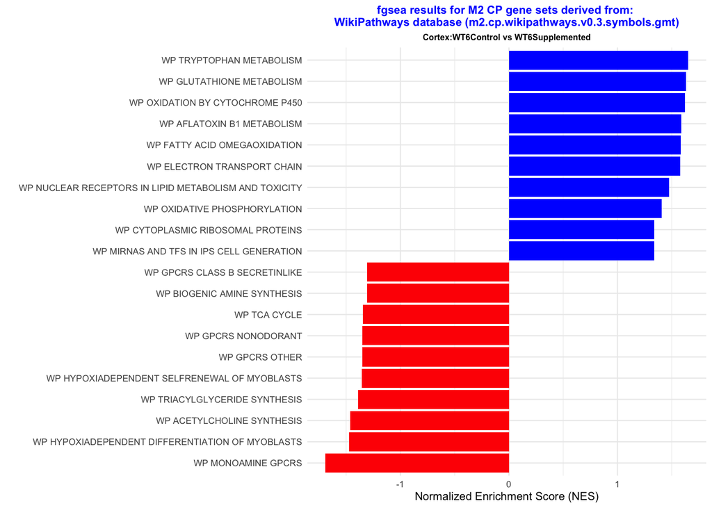

```
## # A tibble: 33,271 × 8
##    genes              volc_plot…¹ log2F…²    padj baseM…³ lfcSE    stat   pvalue
##    <chr>              <chr>         <dbl>   <dbl>   <dbl> <dbl>   <dbl>    <dbl>
##  1 ENSMUSG00000066720 UP          21.1    1.37e-9 5.44e+0 2.79   7.56   4.12e-14
##  2 ENSMUSG00000086756 UP          20.8    1.94e-5 5.47e+0 3.41   6.08   1.17e- 9
##  3 ENSMUSG00000102628 NS          -0.104  1   e+0 4.93e+0 0.700 -0.149  8.82e- 1
##  4 ENSMUSG00000086053 NS          -1.88   1   e+0 1.29e+0 1.71  -1.10   2.71e- 1
##  5 ENSMUSG00000102135 NS          -0.443  1   e+0 2.60e-1 4.96  -0.0894 9.29e- 1
##  6 ENSMUSG00000100764 NS          -0.583  1   e+0 7.79e+0 0.683 -0.854  3.93e- 1
##  7 ENSMUSG00000100635 NS           1.19   1   e+0 1.06e+1 0.998  1.19   2.33e- 1
##  8 ENSMUSG00000100480 NS          -0.430  1   e+0 4.09e+1 0.332 -1.30   1.94e- 1
##  9 ENSMUSG00000100025 NS          -0.230  1   e+0 9.76e+0 0.498 -0.462  6.44e- 1
## 10 ENSMUSG00000051285 NS           0.0486 1   e+0 7.47e+3 0.225  0.216  8.29e- 1
## # … with 33,261 more rows, and abbreviated variable names ¹volc_plot_status,
## #   ²log2FoldChange, ³baseMean
## # ℹ Use `print(n = ...)` to see more rows
```

```
## # A tibble: 190 × 8
##    pathway                        pval   padj log2err     ES   NES  size leadi…¹
##    <chr>                         <dbl>  <dbl>   <dbl>  <dbl> <dbl> <int> <list>
##  1 WP_CHOLESTEROL_METABOLISM_… 2.66e-3 0.168    0.432 -0.590 -1.69    51 <chr>
##  2 WP_CYTOPLASMIC_RIBOSOMAL_P… 3.17e-4 0.0602   0.498 -0.526 -1.64    90 <chr>
##  3 WP_OMEGA9_FATTY_ACID_SYNTH… 2.88e-2 0.514    0.352 -0.730 -1.57    14 <chr>
##  4 WP_HYPERTROPHY_MODEL        2.24e-2 0.514    0.352 -0.669 -1.56    20 <chr>
##  5 WP_ELECTRON_TRANSPORT_CHAIN 2.38e-3 0.168    0.432 -0.491 -1.56    97 <chr>
##  6 WP_INFLAMMATORY_RESPONSE_P… 2.47e-2 0.514    0.352 -0.600 -1.55    30 <chr>
##  7 WP_OXIDATIVE_PHOSPHORYLATI… 1.26e-2 0.479    0.381 -0.525 -1.55    59 <chr>
##  8 WP_NUCLEAR_RECEPTORS        2.79e-2 0.514    0.352 -0.549 -1.47    37 <chr>
##  9 WP_NUCLEAR_RECEPTORS_IN_LI… 3.99e-2 0.541    0.322 -0.571 -1.45    28 <chr>
## 10 WP_GPCRS_SMALL_LIGAND       7.77e-2 0.825    0.262 -0.634 -1.42    17 <chr>
## # … with 180 more rows, and abbreviated variable name ¹leadingEdge
## # ℹ Use `print(n = ...)` to see more rows
```

```
## Hippocampus NES ordered fgsea results saved in file: 'Hippocampus_NES_ordered_fgsea_results_Diet_WT_6_FC0.csv'
```

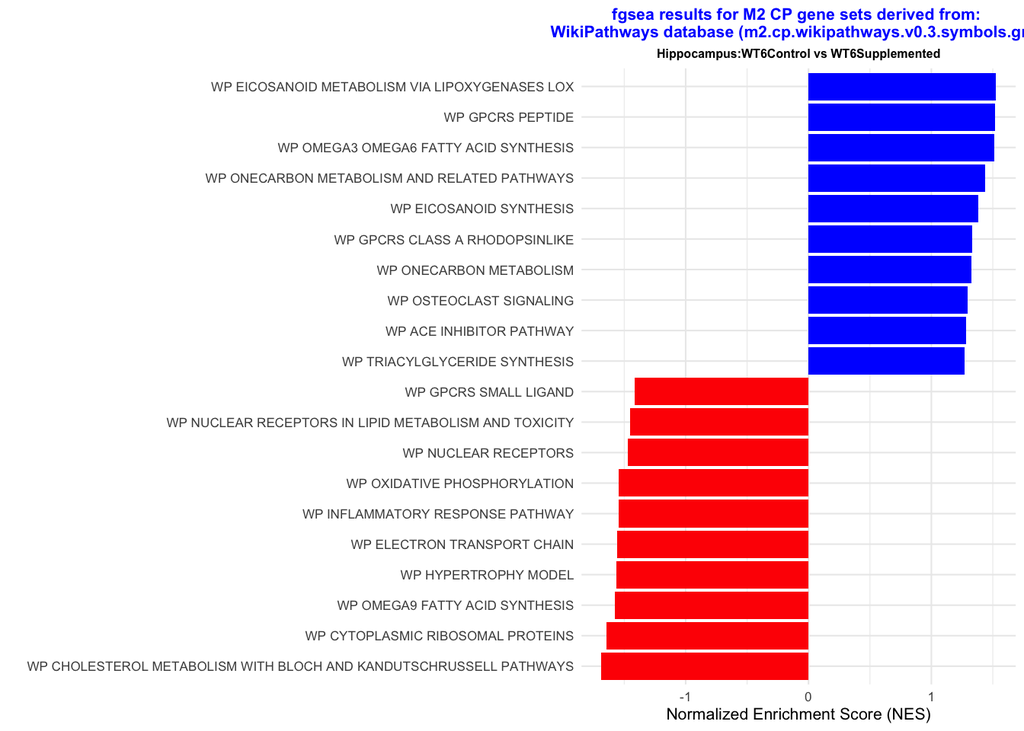